# 迁移学习

## 训练模型

现在，我们就该训练模型了，看看它表现得如何。 回想一下，使用数据生成器时，我们必须显式地设置`steps_per_epoch`：

```python
model.fit(train_it, steps_per_epoch=12, validation_data=test_it, validation_steps=4, epochs=20)
```

```
<tensorflow.python.keras.callbacks.History at 0x7fd61026ee80>
```

## 讨论结果

希望您会发现训练准确率和验证准确率都非常高。这个结果很棒！能够使用小型数据集进行训练并非难事，但由于利用了从 ImageNet 模型迁移过来的知识，我们还能实现模型的高准确率和有效泛化。也就是说，我们的模型能够非常有效地区分 Bo 和不是 Bo 的宠物。

如果看到验证准确率出现一些波动，这也是正常的。我们将在下一节介绍用于改进模型的方法。

## 模型的微调

模型的新层经过训练后，我们还有一个可选的技巧，用于进一步改进模型。这个技巧称为 [微调](https://developers.google.com/machine-learning/glossary#f)。要执行此操作，我们需要先解冻整个模型，然后以极小的 [学习率](https://developers.google.com/machine-learning/glossary#learning-rate) 重新训练模型。这会让预训练的基础层以非常小的步伐进行微调，从而进一步改进模型的性能。

请注意，只有在包含冻结层和新层的模型经过充分训练后才能执行此步骤，这一点很重要。否则，由于我们先前添加到模型中的新的池化层和分类层是随机地初始化的，我们需要对它们的参数进行大量的更新才能实现准确的图像分类。而通过 [反向传播过程](https://developers.google.com/machine-learning/glossary#backpropagation)，在整个模型解冻的状态下，这种对最后两层的大量更新也可能导致预训练层中出现大量更新，从而破坏那些重要的预训练特征。现在这最后2层已经过训练且已收敛，因此再次训练时对模型整体的更新都要小得多（尤其是学习率非常小时），不会破坏前面那些层所预学到的特征。

下面我们就来尝试解冻预训练层，然后微调整个模型：

```python
# Unfreeze the base model
base_model.trainable = True

# It's important to recompile your model after you make any changes
# to the `trainable` attribute of any inner layer, so that your changes
# are taken into account
model.compile(optimizer=keras.optimizers.RMSprop(learning_rate = .00001),  # Very low learning rate
              loss=keras.losses.BinaryCrossentropy(from_logits=True),
              metrics=[keras.metrics.BinaryAccuracy()])
```

```python
model.fit(train_it, steps_per_epoch=12, validation_data=test_it, validation_steps=4, epochs=10)
```

```
<tensorflow.python.keras.callbacks.History at 0x7fd691424860>
```

## 检查预测结果

现在我们已对模型进行了有效训练，下面我们就来为 Bo 创建狗门！首先让我们看一下模型作出的预测。我们会按照为上一个狗门进行图像预处理的方式来预处理这个图像。

```python
import matplotlib.pyplot as plt
import matplotlib.image as mpimg
from tensorflow.keras.preprocessing import image as image_utils
from tensorflow.keras.applications.imagenet_utils import preprocess_input

def show_image(image_path):
    image = mpimg.imread(image_path)
    plt.imshow(image)

def make_predictions(image_path):
    show_image(image_path)
    image = image_utils.load_img(image_path, target_size=(224, 224))
    image = image_utils.img_to_array(image)
    image = image.reshape(1,224,224,3)
    image = preprocess_input(image)
    preds = model.predict(image)
    return preds
```

我们在几个图像上尝试一下，并查看预测结果：

```
array([[-15.432307]], dtype=float32)
```

[figure not shown]

```python
make_predictions('presidential_doggy_door/test/bo/bo_20.jpg')
```

```
array([[21.060276]], dtype=float32)
```

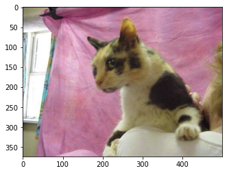

```python
make_predictions('presidential_doggy_door/test/not_bo/121.jpg')
```

看起来负数预测表示图像中是 Bo，而正数预测表示图像中是其他动物。所以，我们可以使用此信息让狗门只允许 Bo 进入！

## 练习：Bo 的狗门

填写下列代码以实现 Bo 的狗门：

```python
def presidential_doggy_door(image_path):
    preds = make_predictions(image_path)
    if preds[0] < 0:
        print("It's Bo! Let him in!")
    else:
        print("That's not Bo! Stay out!")
```

## 答案

单击下方的“...”查看答案。

```
def presidential_doggy_door(image_path):
    preds = make_predictions(image_path)
    if preds[0] < 0:
        print("It's Bo! Let him in!")
    else:
        print("That's not Bo! Stay out!")
```

我们来试一试！

```
That's not Bo! Stay out!
```

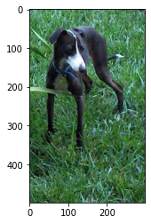

```python
presidential_doggy_door('presidential_doggy_door/test/not_bo/131.jpg')
```

```
It's Bo! Let him in!
```

[figure not shown]

```python
presidential_doggy_door('presidential_doggy_door/test/bo/bo_29.jpg')
```

## 总结

您做得很好！利用迁移学习，您仅使用了一个很小的数据集就构建出了一个高精度的模型。这可谓是一种非常强大的方法，能够决定项目是获得成功还是无法取得进展。我们希望这些方法今后能够在类似的情况下帮助您摆脱困境！

您可以从 [NVIDIA 迁移学习工具包](https://developer.nvidia.com/tlt-getting-started) 中获得大量有用的迁移学习资源。

### 清理显存

继续进行后续内容之前，请执行以下单元清理 GPU 显存。

```python
import IPython
app = IPython.Application.instance()
app.kernel.do_shutdown(True)
```

```
{'status': 'ok', 'restart': True}
```

## 下一步

目前为止，这次研讨会的重点主要聚焦于图像分类。下一节中，为了更全面地介绍深度学习，我们将转而处理序列数据，并将采用不同的方法。

请继续学习下一节：*序列数据*。